# Public Concensus About Earthquakes

Public Analysis of San Andreas Fault and Earthquake Perception

Michaela Marino

```python
#Import pandas and matplotlib
import pandas as pd
import matplotlib.pyplot as plt
% matplotlib inline

#csv file
earthquakes = pd.read_csv("earthquake_data.csv", parse_dates=['US Region'])
```

## Who doesn't love a good History channel documentary?

When I was a kid, I watched documentaries all the time. One of the most common topics on the History channel was the possibility of a catastrophic disaster and what the consequences would look like in today's world. The data collected in this set reminds me of these documentaries, but brings in a more realistic take on how the population feels about the idea of a minor or massive earthquake taking place. This data set takes a look at the population of the US and asks questions pertaining to the threat of the San Andreas fault annd earthquakes in general in everyday life. There are a total of 1,014 responses.

## 1. How does familiarity with the San Andreas fault line affect nervousness about the possibility of a big, catastrophic earthquake?

My first question focues on familiarity and nervousness of the general population in terms of the possibility of a large earthquake or natural disaster. The results are shown below.

```
Text(0.5,0,'Frequency of Answer')
```

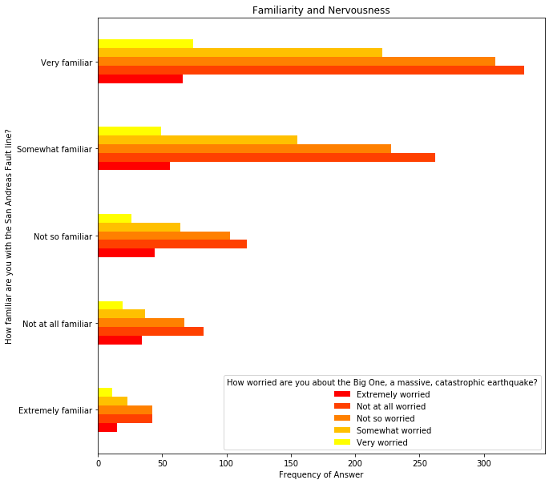

```python
#Familiarity and Nervousness
question1 = pd.crosstab(earthquakes['How familiar are you with the San Andreas Fault line?'], earthquakes['How worried are you about the Big One, a massive, catastrophic earthquake?'])

#Visualization
question1 = question1.cumsum()
plt.clf()
question1.plot(kind = 'barh', figsize = (10,10), colormap = 'autumn')
plt.title('Familiarity and Nervousness')
plt.xlabel('Frequency of Answer')
```